# ENARES agrupamiento

Diego Alvarado Rivera, María Paz Herrera Quiroz, Martín Sanchez

## Encuesta Nacional Sobre Relaciones Sociales

La ENARES es una encuesta llevada a cabo por el INEI que tiene como objetivo recolectar datos que permitan cuantificar el nivel de violencia familiar y dar soporte a las políticas de salud pública relacionadas con este problema.

En este trabajo se considera la ENCUESTA NACIONAL SOBRE RELACIONES SOCIALES 2019 DIRIGIDA A VARONES Y MUJERES DE 18 Y MÁS AÑOS DE EDAD del año 2019.

En el siguiente link puede acceder al cuestionario link

## Carga de los datos

En primer lugar, se deben importar los datos y modificar la codficación de algunas variables para facilitar el análisis.

```r
library(ggplot2)
library(tidyr)
library(dplyr)
library(plyr)


# cargar los datos
data <- read.csv("datasets/ENARES/enares_bd.csv")
#head(data, 20)

#cambiar el nombre de la primera columna
colnames(data)[1] <- "DEPARTAMENTO"

# cambiar la codificación de la variable sexo
data$C1P207 <- mapvalues(data$C1P207, from=c(1, 2), to=c("hombre", "mujer")) # 1: varon, 2:mujer
data$C1P207 <- as.factor(data$C1P207)


# cambiar la codificación de la variables relacionadas a la violencia durante la niñez
data$C1P318_1 <- mapvalues(data$C1P318_1, from=c(1, 2), to=c(1, 0)) # 1:SI, 2:No
data$C1P318_2 <- mapvalues(data$C1P318_2, from=c(1, 2), to=c(1, 0)) # 1:SI, 2:No
data$C1P318_3 <- mapvalues(data$C1P318_3, from=c(1, 2), to=c(1, 0)) # 1:SI, 2:No

# Cambiar el tipo de dato de la varaible educación a factor

data$C1P210 <- mapvalues(data$C1P210, from=c(1, 2, 3, 4, 5, 6, 7, 8),
                           to=c("Sin nivel", "Inicial", "Prim", "Secun",
                                "Basica Especi",  "Sup no basi", "Sup univer",  "Maes/Doct"))

data$C1P210 <- factor(data$C1P210, ordered=TRUE,
                      levels=c("Sin nivel", "Prim", "Secun", "Sup no basi", "Sup univer",
                               "Maes/Doct"))
```

## Clusterización

A continuación se muestran las preguntas del grupo 401 y 402 de la encuesta, las cuales tiene como tema la violencia hacia los niños y mujeres.

Estas pregunatas servirán para descubrir perfiles de tolerancia hacia la violencia. Para esto se aplicará un algoritmo de clustering (k-means) a estas 20 variables.

Cada pregunta tiene 4 opciones: Muy en desacuerdo (1), En desacuerdo (2), De acuerdo (3), Muy de acuerdo (4).

### Preguntas 401

- **Preg 401.1**: Un varón tiene el derecho a usar la fuerza para corregir a su esposa o pareja, si ella coquetea con otros varones
- **Preg 401.2**: Una mujer que se viste provocativamente y con ropa reveladora está buscando que la acosen sexualmente
- **Preg 401.3**: Si alguien está en su casa y escucha que un vecino está golpeando a su mujer, debe pedir ayuda
- **Preg 401.4**: La violencia contra la mujer en el hogar es inaceptable y debería ser castigada por la ley
- **Preg 401.5**: La mujer que es infiel a su esposo o pareja debe tener alguna forma de castigo por él
- **Preg 401.6**: El varón cela a su esposa o pareja porque así le demuestra que la ama
- **Preg 401.7**: La mujer siempre debe estar dispuesta a tener relaciones sexuales cuando su esposo o pareja lo desea
- **Preg 401.8**: La mujer debe permitir todo lo que su esposo o pareja le pida sexualmente
- **Preg 401.9**: Si la mujer le falta el respeto a su esposo o pareja, ella merece alguna forma de castigo
- **Preg 401.10**: La mujer debe cumplir primero con su rol de madre, esposa o ama de casa, y después realizar sus propios sueños

### Preguntas 402

- **Preg 402.1**: De conocer de un caso de abuso sexual a una niña, niño o adolescente, es mejor no intervenir para evitarse problemas
- **Preg 402.2**: Se debe utilizar el castigo físico sin lesionar a la niña, niño o adolescente
- **Preg 402.3**: A los hijos varones, es necesario insultarles o pegarles para que aprendan a ser varoncitos
- **Preg 402.4**: Los únicos que tienen derecho a pegarle a las niñas, niños o adolescentes son sus padres
- **Preg 402.5**: Si alguien está en su casa y escucha que un vecino está golpeando a su hija o hijo debería pedir ayuda
- **Preg 402.6**: Cuando una niña o niño deja de ser bebé, ya se le puede aplicar el castigo físico para corregirlo
- **Preg 402.7**: Las niñas, niños y adolescentes a los cuales no se les pega, se vuelven malcriados y ociosos
- **Preg 402.8**: Los padres quieren que sus hijas o hijos tengan éxito en la vida y para conseguirlo pueden incluso recurrir al castigo físico
- **Preg 402.9**: La violencia contra niñas, niños y adolescentes es inaceptable y debería ser castigado por la ley
- **Preg 402.10**: La niña, niño o adolescente no debe ser separado de su hogar, aun cuando sus padres acostumbren maltratarlo

## Selección del número de clusters

El primer paso consiste en determinar el número apropiado de clusters. En el siguiente gráfico se muestra la inercia en función del número de clusters.

Se observa que a partir de k=3, la inclusión de nuevos grupos no disminuye de forma significativa la inercia. Así, se concluye que el número apropiado de clusters es igual a 3.

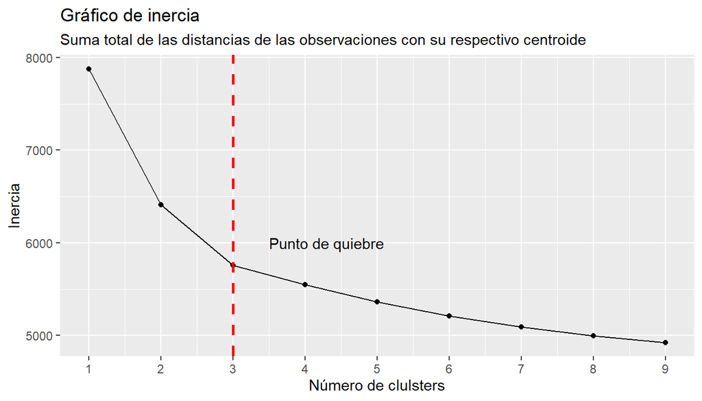

```r
set.seed(0)

# seleccionar las variables a clusterizar
data_clustering <- subset(data, select=14: 33)

k.max <- 9

clustering_results <- data.frame(row.names = 1:k.max)
clustering_results$n_clusters <-  1:(k.max)
clustering_results$wss <-  1:(k.max)

for(n_clusters in 1:(k.max)) {
  kmeans_res <- kmeans(data_clustering, n_clusters, iter.max = 1000, nstart = 15)
  clustering_results$wss[n_clusters] <- kmeans_res$tot.withinss
}

ggplot(clustering_results, aes(x=n_clusters, y=wss)) + geom_line() + geom_point() +
  ylab("Inercia") + xlab("Número de clulsters") +
  labs(title="Gráfico de inercia",
       subtitle = "Suma total de las distancias de las observaciones con su respectivo centroide") +
  geom_vline(xintercept = 3, linetype="dashed", color="red", size=1) +
  scale_x_continuous(breaks=1:10) +
  scale_y_continuous(breaks=seq(5000, 8000, 1000)) +
  annotate("text", x = 4.3, y = 6000, label = "Punto de quiebre")
```

```r
# correr el algotimo con el número seleccionado de clusters
set.seed(0)
kmeans_res <- kmeans(data_clustering, 3, iter.max = 1000, nstart = 10)
```

## Resultados del algoritmo k-means

En la siguiente figura se muestra la puntuación promedio en cada pregunta por cada uno de los grupos.

Se observa que las personas menos tolerantes a la violencia contra los niños (C) son más propensas a penalizarla por ley (D), de forma similar con la violencia hacia las mujeres (A) y (B). Asimismo, las personas más tolerantes a la violencia contra los niños (C) también son más tolerantes respecto a la violencia contra las mujeres (A).

Finalmente se procede a perfilar a cada clúster

- **cluster 2**: Es el menos tolerante a la violencia. Se opone a la violencia contra niños y mujeres, y piensa que estas deberían ser penalizada por la ley.
- **cluster 3**: Es el más tolerante a la violencia, tanto hacia niños como hacia las mujeres.
- **cluster 1**: Su nivel de tolerancia hacia la violencia (hacia los niños y hacia las mujeres) es intermedio.

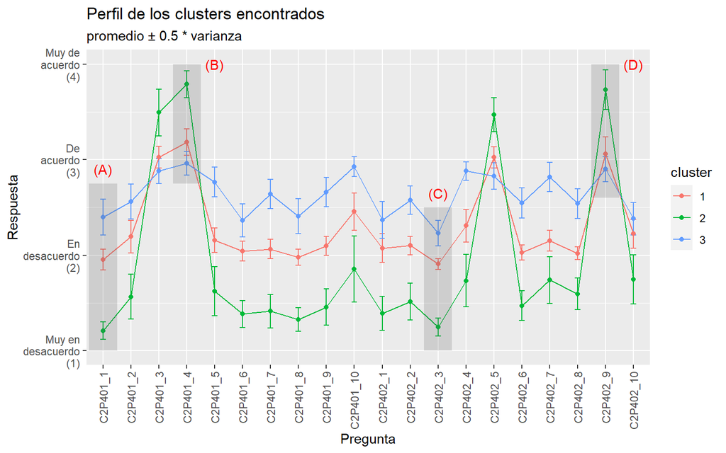

```r
data_clustering$cluster <-  kmeans_res$cluster

temp_df <- data_clustering %>%
  group_by(cluster) %>%
  summarise_all(.funs=c(mean))

temp_df <-  gather(temp_df, variable, promedio, C2P401_1:C2P402_10, factor_key=TRUE)

temp_df_2 <- data_clustering %>%
  group_by(cluster) %>%
  summarise_all(.funs=c(var))

temp_df_2 <-  gather(temp_df_2, variable, sd, C2P401_1:C2P402_10, factor_key=TRUE)


temp_df$sd <- temp_df_2$sd * 0.5
temp_df$cluster <- as.factor(temp_df$cluster)



valores <- c("Muy en\ndesacuerdo\n(1)",
             "En\ndesacuerdo\n(2)",
             "De\nacuerdo\n(3)",
             "Muy de\nacuerdo\n(4)")


ggplot(temp_df, aes(x=variable,
                    y=promedio)) +
  geom_errorbar(aes(ymax= promedio + sd, ymin= promedio - sd, color=cluster, width=0.2)) +
  geom_point(aes(color=cluster)) +
  geom_line(aes(group=cluster, color=cluster)) +
  theme(axis.text.x = element_text(angle = 90, vjust = 0.5, hjust=1)) +
  ylab("Respuesta") + xlab("Pregunta") +
  labs(title="Perfil de los clusters encontrados",
       subtitle="promedio ± 0.5 * varianza") +
  ylim(1, 4) +
  annotate("rect", xmin = 0.5, xmax = 1.5, ymin = 1, ymax = 2.75, alpha = 0.2) +
  annotate("rect", xmin = 3.5, xmax = 4.5, ymin = 2.75, ymax = 4, alpha = 0.2) +
  annotate("rect", xmin = 12.5, xmax = 13.5, ymin = 1, ymax = 2.5, alpha = 0.2) +
  annotate("rect", xmin = 18.5, xmax = 19.5, ymin = 2.6, ymax = 4, alpha = 0.2) +
  scale_y_continuous(label=function(x){return(paste(valores[x]))}) +
  theme(axis.text.y=element_text(angle = 0, vjust = 0.5)) +
  annotate("text", x = 1, y = 2.9, label = "(A)", color="red") +
  annotate("text", x = 5, y = 4, label = "(B)", color="red") +
  annotate("text", x = 13, y = 2.65, label = "(C)", color="red") +
  annotate("text", x = 20, y = 4, label = "(D)", color="red")
```

```r
# crear la nueva variable cluster
data$cluster <-  kmeans_res$cluster
data$cluster <- mapvalues(data$cluster, from=c(1, 2, 3),
                          to=c("Media_tolerancia", "Baja_tolerancia", "Alta_tolerancia"))

data$cluster <- factor(data$cluster, order=TRUE,
                       levels=c("Baja_tolerancia", "Media_tolerancia", "Alta_tolerancia"))
```

# Perfilamiento de los clusters

A continuación, se procede a examinar la relación entre los diferentes perfiles de tolerancia a la violencia con otras variables presentes en la base de datos como sexo, educación y exposición a la violencia durante la niñez.

En el siguiente gráfico se muestra la proporción de mujeres y hombres encuestados en cada uno de los clusters. No se observa una diferencia significativa entre los clusters. Sin embargo, la proporción de mujeres en el grupo de baja tolerancia hacia las mujeres es ligeramente mayor al de los hombres.

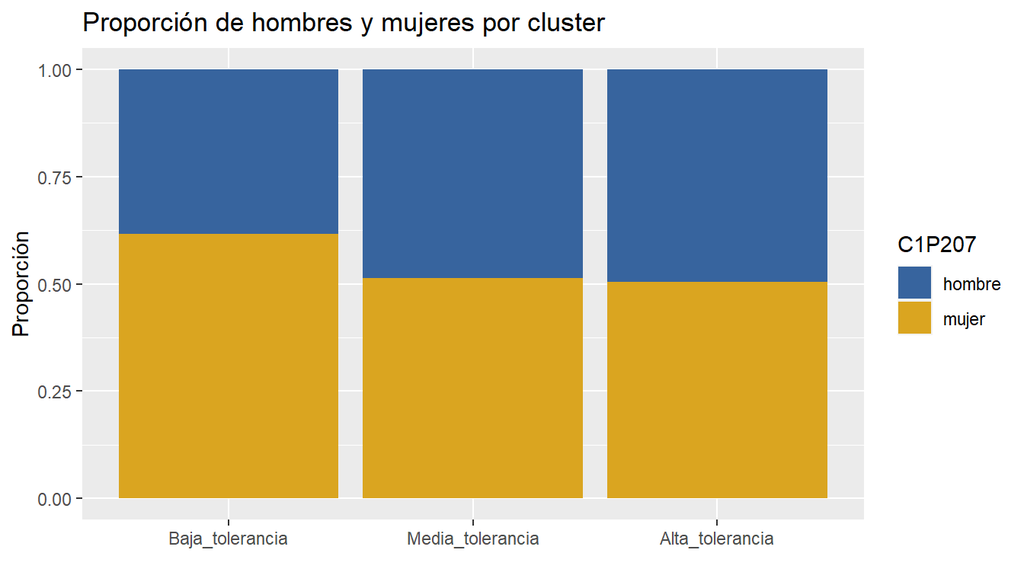

```r
# graficar
ggplot(data,aes(x = cluster, fill = C1P207)) +
  geom_bar(position = "fill") +
  scale_fill_manual(values=c("#37649E", "#DAA520"))+
  ggtitle("Proporción de hombres y mujeres por cluster") +
  ylab("Proporción") + xlab("")
```

# Perfil de exposición a la violencia de los clusters

A continuación, se analiza la pregunta C1P918, la cual está relacionada a la exposición a la violencia durante la niñez:

**C1P918**: Alguna vez, cuando usted era niña/niño, hasta la edad de 11 años:

- **C1P318_1**: ¿Recuerda si entre sus padres había golpes?
- **C1P318_2**: ¿Recuerda si las personas con las que vivía en su hogar le pegaban?
- **C1P318_3**: ¿Recuerda si las personas con las que vivía en su hogar la/lo insultaban o la/lo ofendían?

En el siguiente gráfico se puede observar que existe una relación entre la tolerancia a la violencia y la exposición esta. El grupo de mayor tolerancia a la violencia, en general, sufrió una mayor exposición a esta durante la niñez y lo contrario ocurre con el grupo de menor tolerancia.

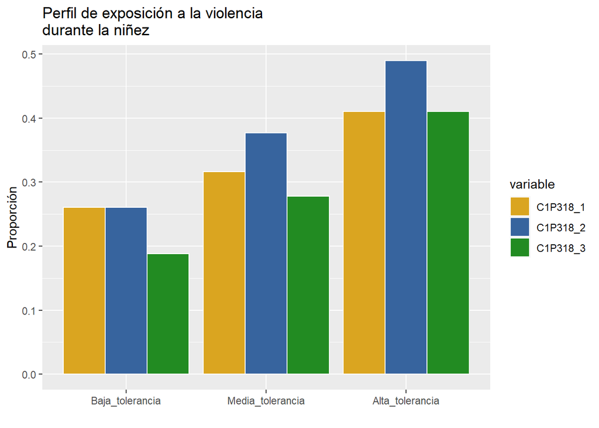

```r
temp_df <- data %>%
  group_by(cluster) %>%
  summarise_at(c("C1P318_1", "C1P318_2", "C1P318_3"), mean, na.rm = TRUE)

temp_df <- temp_df %>% gather(variable, valor, -c(cluster))

p1 <- ggplot(data=temp_df, aes(x=cluster, y=valor, fill=variable)) +
  geom_bar(stat="identity", position="dodge", color="white") +
  scale_fill_manual(values=c("#DAA520", "#37649E", "#228B22"))


p1 + labs(title="Perfil de exposición a la violencia\ndurante la niñez") +ylab("Proporción") +
  xlab("")
```

# Perfil de educación de los clusters

Finalmente, se analiza la pregunta C1P210, la cual está relacionada al nivel educativo de la persona encuestada.

**C1P210** : ¿Cuál fue el último nivel y grado o año de estudios que aprobó?

- Sin nivel (1)
- Educación inicial (2)
- Primaria (3)
- Secundaria (4)
- Básica especial (5)
- Superior no universitaria (6)
- Superior universitaria (7)
- Maestría/Doctorado (8)

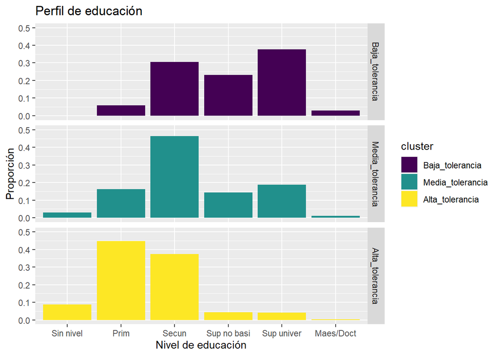

```r
p1 <- ggplot(data, aes(x = C1P210, fill=cluster)) +
  geom_bar(aes(y = (..count..)/tapply(..count..,..PANEL..,sum)[..PANEL..])) +
  ylim(0, 0.5)+ xlab("Nivel de educación") +
  ylab("Proporción") +
  facet_grid(rows="cluster") + ggtitle("Perfil de educación")

p1
```

# Extrapolación de los resultados

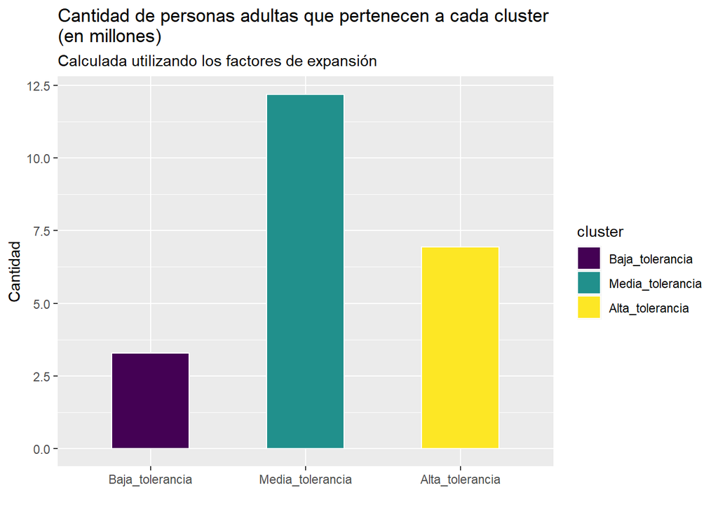

```r
#library(grid)
#library(gridExtra)

temp_df <- data %>%
  group_by(cluster) %>%
  summarize_at(.vars=c("factor_hym"), .funs=c(sum))


p1 <- ggplot(data=temp_df, aes(x=cluster, y=factor_hym/1000000, fill=cluster)) +
  geom_bar(stat="identity", position="dodge", color="white", width = 0.5) + xlab("Perú") +
  labs(title= "Cantidad de personas adultas que pertenecen a cada cluster\n(en millones)",
       subtitle = "Calculada utilizando los factores de expansión")   +
  ylab("Cantidad") + xlab("")

p1
```

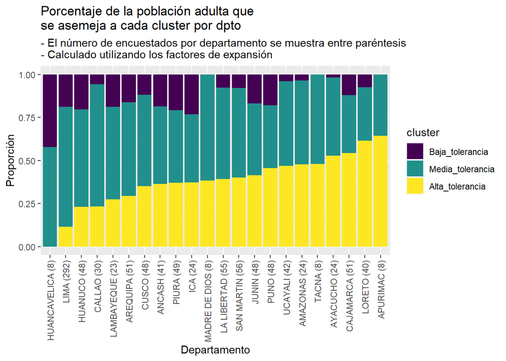

```r
# 1.- hallar la cantidad de encuestados por departamento
temp_df_1 <- data %>%
  group_by(DEPARTAMENTO) %>%
  summarize_at(.vars=c("factor_hym", "factor_hym"), .funs=c(sum, length))

# concatenar el nombre del departamento y el número de encuestados
temp_df_1$dptoCount <- paste(temp_df_1$DEPARTAMENTO, " (", temp_df_1$fn2, ")", sep = "")

dpto_names <- as.vector(temp_df_1$DEPARTAMENTO)
dpto_names_count <- as.vector(temp_df_1$dptoCount)

#dpto_names
#dpto_names_count


# 2.- Hallar la proporción de personas pertenecientes al grupo de alta tolerancia por dpto
temp_df_2 <- data %>%
  group_by(DEPARTAMENTO) %>%
  summarize_at(.vars=c("factor_hym"), .funs=c(sum))

temp_df_2$AT <- 1:22

c=1
for(i in unique(temp_df_2$DEPARTAMENTO)){
  dpto_data <- data[(data$DEPARTAMENTO==i) & (data$cluster=="Alta_tolerancia"), ]
  if (nrow(dpto_data)!=0){
    temp_df_2$AT[c] <- sum(dpto_data$factor_hym)
  }else{
    temp_df_2$AT[c] <- 0
  }
  c <- c+1
}

dpto_names <- unique(temp_df_2$DEPARTAMENTO)
dpto_props <- temp_df_2$AT / temp_df_2$factor_hym

dpto_names_count_ord <- dpto_names_count[order(dpto_props)]
#dpto_names_count_ord

# halar la cantidad de personas que pertenecen a cada cluster por cada depto
temp_df <- data %>%
  group_by(cluster, DEPARTAMENTO) %>%
  summarize_at(.vars=c("factor_hym"), .funs=c(sum))

# modificar el nombre del departamento
temp_df$DEPARTAMENTO <- mapvalues(temp_df$DEPARTAMENTO, from = dpto_names, to=dpto_names_count)


# graficar
p2 <- ggplot(temp_df, aes(fill=cluster, y=factor_hym, x=factor(DEPARTAMENTO, ordered = TRUE,
                                                               levels=dpto_names_count_ord))) +
  geom_bar(position="fill", stat="identity") +
  theme(axis.text.x = element_text(angle = 90, vjust = 0.5, hjust=1)) +
  xlab("Departamento") + ylab("Proporción") +
  labs(title="Porcentaje de la población adulta que\nse asemeja a cada cluster por dpto",
       subtitle = "- El número de encuestados por departamento se muestra entre paréntesis\n- Calculado utilizando los factores de expansión")

p2
```